# Performance Evaluation of Terapixel Rendering

#### Syed Mohib Raza - 200740241

January 21, 2021

Table of Content

## 1. Abstract

With the increasing use of cloud technologies, there is a need to find more information to enhance efficiency and further reduce cost and power. This can be done through performance evaluation using data analysis. This project aims to extract information from the dataset created from the application checkpoint and system metric output from a production of a terapixel image to pinpoint the area on which optimization should be focused.

## 2. Introduction

Terapixel images offer an intuitive, accessible way to present information sets to stakeholders, allowing viewers to interactively browse big data across multiple scales. The terapixel image is an image that contains over 1 trillion pixels, which are overwhelming in size and difficult to render [1] on a local machine. However, if deployed on the cloud, it can aid authorities from various domains, from healthcare to national security, as the rendering is done over the cloud and hence is not restricted to hardware resources.  
Through the data provided by Newcastle University, we take on the challenge of highlighting and developing the understanding of the data and finding possible ways to improve the performance of the nodes through exploratory data analysis. The report presents data understanding by using the CRISP-DM cycle. Through this methodology, insights about the data are collected and used to form a hypothesis for later analysis, doing this repeatedly in order (some flexibility is possible [2]) with the aim for modeling/deployment to stakeholders. This report involves frequency analyzing, merging data, cleaning data, and finding patterns of GPU performance through different analytical processes.  
[1] Wang, C.-W., Huang, C.-T., Hung, C.-M., 2015. VirtualMicroscopy: ultra-fast interactive microscopy of gigapixel/terapixel images over internet. Scientific reports 5, 14069. [2] Chapman, P., Clinton, J., Kerber, R., Khabaza, T., Reinartz, T., Shearer, C., Wirth, R., 2000. CRISP-DM 1.0 Step-by-step data mining guide.

## 3. Motivation/Business Understanding

Cloud computing with IoT has gained a lot of popularity in recent years since it continues to provide unprecedented possibilities; Yet, it comes with a significant cost aspect known as "Cloud Economics." If the workload in the cloud is not properly optimised, the total cost of ownership (TCO) will rise, resulting in worse returns on investment. As a result, analysing performance measurements from cloud supercomputers has become critical in order to properly calibrate the process. Despite the fact that this initiative is unrelated to any business or organisation, it must have a positive influence on stakeholders' concerns that have not been addressed previously in its area.

## 4. Objective

The goal of this report is to investigate bottlenecks and trends in the use of GPUs for terapixel rendering operations of Newcastle Upon Tyne over a cloud computing platform. The following are the expected criteria to be explored:

- Parallel workload distribution by the cloud architecture.
- Measure and analyse memory Usage
- Event type runtime pattern and domination.
- Relationship between GPU statistics.

[1] Micikevicius, Paulius. "GPU performance analysis and optimization." In GPU technology conference, vol. 3. 2012. [2] Bradley, Thomas. "GPU performance analysis and optimisation." NVIDIA Corporation (2012). [3] Yamaoka, S., Doerr, K.-U., Kuester, F., 2011. Visualization of high-resolution image collections on large tiled display walls. Future Generation Computer Systems 27, 498–505.

## 5. Tools & Methodologies

Flexibility is possible [1] in CRISP-DM and using it the data preparation will be carried out before exploration, and understanding. Their will be no modelling and deploymet steps since no modelling will occur in this project but it can be regarded in future works.  
**Rationale** - Cleaning the datasets - Removal of unwanted observtion (duplicate or irrelevant data) to prepare the data for exploration. - Merging - Preparing of the integrated data set by aggregating required fields. - EDA - Finding insights about data structure, data relationships or data patterns. **Tools** Use of python programming language is done and to promote reproducibility jupyter notebook is used with proper instructions in readme to produce the report. This ensures everything is in one place with good shareability. GitHub is used for version control to safe guard/minimise from the risks of accidental or mistaken changes ensuring that sevral developmental routes can be controlled easily without worrying of not being able to revert back when modifications are scrapped.  
[1] Chapman, P., Clinton, J., Kerber, R., Khabaza, T., Reinartz, T., Shearer, C., Wirth, R., 2000. CRISP-DM 1.0 Step-by-step data mining guide.

```python
# Install the below mentioned libraries before running this notebook
# Use [pip install "package name"]
import pandas as pd
import numpy as np
import seaborn as sns
import matplotlib.pyplot as plt
from datetime import datetime
```

## 6. Data Description

The datasets provided are based on the results from a run of three 3 jobs (levels 4, 8 and 12 of the terapixel image) using 1024 GPU nodes over the public cloud, recording timings of the rendering, GPU performance, and which image details are being rendering. This data is divided into three separated datasets stored in .csv files: - gpu.csv: GPU status metrics (temperatures, memory usage, etc.). - application-checkpoints.csv: checkpoint events throughout render job saved by the application. - task-x-y.csv: Co-ordinates of image parts being rendered in tasks carried by the application for the job.

**Data Features**

- timestamp (textual): Timestamp for tuple in ’YYYY-MM-DD H:M:S.f’ format for start and end of event.
- gpuSerial (nuerical): Serial number assigned to physical gpu card.
- hostname (textual): Unique system ID assigned to the Machine GPU runs from by Microsoft Azure.
- gpuUUID (textual): Unique GPU ID assigned to the Machine GPU runs from by Microsoft Azure.
- powerDrawWatt (numerical): Average power draw of system (Watts) for event.
- gpuTempC (numerical): The Average GPU temperature (Celsius) for event.
- gpuUtilPerc (numerical): The average GPU utilisation % (0-100) for event.
- gpuMemUtilPerc (numerical): The average GPU memory usage % (0-100) for event.
- eventName (textual): Name of current event occurring in the rendering process.

  Possible values

  ```
    - TotalRender: The whole task itself
    - Render: Image tile being rendered
    - Saving Config: Configuration overhead
    - Tiling: Tile postprocessing
    - Uploading: Output uploading to Azure Blob Storage
  ```

- eventType (textual): Possible values - 'Start' & 'Stop' - Signifies starting and stopping of the event/process.
- jobId (textual) - ID of the Azure batch job.
- taskId (textual) - ID of the Azure batch task.
- x (numerical): X coordinate of tile being rendered
- y (numerical): Y coordinate of tile being rendered
- level (numerical): Visualisation level (zoom) within the terapixel map (4, 8, 12)

#### 6.1 Loading Datasets

```python
df_gpu = pd.read_csv("data/gpu.csv")
```

```python
df_app = pd.read_csv("data/application-checkpoints.csv")
```

```python
df_task = pd.read_csv("data/task-x-y.csv")
```

#### 6.2 GPU Dataset

```python
# Printing first few lines
df_gpu.head()
```

|  | timestamp | hostname | gpuSerial | gpuUUID | powerDrawWatt | gpuTempC | gpuUtilPerc | gpuMemUtilPerc |
| --- | --- | --- | --- | --- | --- | --- | --- | --- |
| 0 | 2018-11-08T08:27:10.314Z | 8b6a0eebc87b4cb2b0539e81075191b900001C | 323217055910 | GPU-1d1602dc-f615-a7c7-ab53-fb4a7a479534 | 131.55 | 48 | 92 | 53 |
| 1 | 2018-11-08T08:27:10.192Z | d8241877cd994572b46c861e5d144c85000000 | 323617020295 | GPU-04a2dea7-f4f1-12d0-b94d-996446746e6f | 117.03 | 40 | 92 | 48 |
| 2 | 2018-11-08T08:27:10.842Z | db871cd77a544e13bc791a64a0c8ed50000006 | 323217056562 | GPU-f4597939-a0b4-e78a-2436-12dbab9a350f | 121.64 | 45 | 91 | 44 |
| 3 | 2018-11-08T08:27:10.424Z | b9a1fa7ae2f74eb68f25f607980f97d7000010 | 325217085931 | GPU-ad773c69-c386-a4be-b214-1ea4fc6045df | 50.23 | 38 | 90 | 43 |
| 4 | 2018-11-08T08:27:10.937Z | db871cd77a544e13bc791a64a0c8ed50000003 | 323217056464 | GPU-2d4eed64-4ca8-f12c-24bc-28f036493ea2 | 141.82 | 41 | 90 | 47 |

```python
# Checking diemnsions of data
df_gpu.shape
```

```
(1543681, 8)
```

```python
# Finding duplicates acoss all columns
duplicateRows = df_gpu[df_gpu.duplicated()]
```

```python
# Dropping duplicate rows
df_gpu = df_gpu.drop_duplicates(keep=False)
df_gpu.shape
```

```
(1543663, 8)
```

```python
duplicateRows = df_gpu[df_gpu.duplicated(['gpuUUID'])]
```

```python
df_gpu_test = df_gpu.drop_duplicates(subset=['gpuUUID'])
df_gpu_test.shape
```

```
(1024, 8)
```

#### 6.3 Application Checkpoint Dataset

```python
# Printing first few lines
df_app.head()
```

|  | timestamp | hostname | eventName | eventType | jobId | taskId |
| --- | --- | --- | --- | --- | --- | --- |
| 0 | 2018-11-08T07:41:55.921Z | 0d56a730076643d585f77e00d2d8521a00000N | Tiling | STOP | 1024-lvl12-7e026be3-5fd0-48ee-b7d1-abd61f747705 | b47f0263-ba1c-48a7-8d29-4bf021b72043 |
| 1 | 2018-11-08T07:42:29.842Z | 0d56a730076643d585f77e00d2d8521a00000N | Saving Config | START | 1024-lvl12-7e026be3-5fd0-48ee-b7d1-abd61f747705 | 20fb9fcf-a927-4a4b-a64c-70258b66b42d |
| 2 | 2018-11-08T07:42:29.845Z | 0d56a730076643d585f77e00d2d8521a00000N | Saving Config | STOP | 1024-lvl12-7e026be3-5fd0-48ee-b7d1-abd61f747705 | 20fb9fcf-a927-4a4b-a64c-70258b66b42d |
| 3 | 2018-11-08T07:42:29.845Z | 0d56a730076643d585f77e00d2d8521a00000N | Render | START | 1024-lvl12-7e026be3-5fd0-48ee-b7d1-abd61f747705 | 20fb9fcf-a927-4a4b-a64c-70258b66b42d |
| 4 | 2018-11-08T07:43:13.957Z | 0d56a730076643d585f77e00d2d8521a00000N | TotalRender | STOP | 1024-lvl12-7e026be3-5fd0-48ee-b7d1-abd61f747705 | 20fb9fcf-a927-4a4b-a64c-70258b66b42d |

```python
# Checking diemnsions of data
df_app.shape
```

```
(660400, 6)
```

#### 6.4 Test Dataset

```python
# Printing first few lines
df_task.head()
```

|  | taskId | jobId | x | y | level |
| --- | --- | --- | --- | --- | --- |
| 0 | 00004e77-304c-4fbd-88a1-1346ef947567 | 1024-lvl12-7e026be3-5fd0-48ee-b7d1-abd61f747705 | 116 | 178 | 12 |
| 1 | 0002afb5-d05e-4da9-bd53-7b6dc19ea6d4 | 1024-lvl12-7e026be3-5fd0-48ee-b7d1-abd61f747705 | 142 | 190 | 12 |
| 2 | 0003c380-4db9-49fb-8e1c-6f8ae466ad85 | 1024-lvl12-7e026be3-5fd0-48ee-b7d1-abd61f747705 | 142 | 86 | 12 |
| 3 | 000993b6-fc88-489d-a4ca-0a44fd800bd3 | 1024-lvl12-7e026be3-5fd0-48ee-b7d1-abd61f747705 | 235 | 11 | 12 |
| 4 | 000b158b-0ba3-4dca-bf5b-1b3bd5c28207 | 1024-lvl12-7e026be3-5fd0-48ee-b7d1-abd61f747705 | 171 | 53 | 12 |

```python
# Checking diemnsions of data
df_task.shape
```

```
(65793, 5)
```

## 7. Data Preprocessing

This section concentrated on the process of data cleaning and wrangling along with merging datasets. Here we create function to convert timestamp to our format and we use merge_check_task function to merge application-checkpoints dataset and task dataset using left join on taskId and jobId.

```python
TIMESTAMP_FORMAT = '%Y-%m-%dT%H:%M:%S.%fZ'
def timestamp_conv(df):
    """
    Converts a timestamp to datetime

    Parameters
    ----------
    df
        dataframe to convert to datetime
    ----------
    float
        converted timestamp
    """

    df = df.apply(lambda x: (datetime.strptime(x, TIMESTAMP_FORMAT)))
    return(df)
```

```python
def merge_check_task(df_checkpoints, df_tasks):

    """"
    Merging application check point and task (left join) taskId and jobId

    Parameters
    ----------
    check_task_df
        application checkpoints and tasks megred dataframe to merge with gpu df

    gpu_df
        gpu dataframe to merge
    """

    df_check_task = df_checkpoints.merge(df_tasks,
                                     on=['taskId', 'jobId'], how='left')
    return (df_check_task)
df_check_task = merge_check_task(df_app, df_task)
```

```python
# Converting timestamp for gpu data

df_gpu['timestamp'] = timestamp_conv(df_gpu['timestamp'])
df_gpu
```

|  | timestamp | hostname | gpuSerial | gpuUUID | powerDrawWatt | gpuTempC | gpuUtilPerc | gpuMemUtilPerc |
| --- | --- | --- | --- | --- | --- | --- | --- | --- |
| 0 | 2018-11-08 08:27:10.314 | 8b6a0eebc87b4cb2b0539e81075191b900001C | 323217055910 | GPU-1d1602dc-f615-a7c7-ab53-fb4a7a479534 | 131.55 | 48 | 92 | 53 |
| 1 | 2018-11-08 08:27:10.192 | d8241877cd994572b46c861e5d144c85000000 | 323617020295 | GPU-04a2dea7-f4f1-12d0-b94d-996446746e6f | 117.03 | 40 | 92 | 48 |
| 2 | 2018-11-08 08:27:10.842 | db871cd77a544e13bc791a64a0c8ed50000006 | 323217056562 | GPU-f4597939-a0b4-e78a-2436-12dbab9a350f | 121.64 | 45 | 91 | 44 |
| 3 | 2018-11-08 08:27:10.424 | b9a1fa7ae2f74eb68f25f607980f97d7000010 | 325217085931 | GPU-ad773c69-c386-a4be-b214-1ea4fc6045df | 50.23 | 38 | 90 | 43 |
| 4 | 2018-11-08 08:27:10.937 | db871cd77a544e13bc791a64a0c8ed50000003 | 323217056464 | GPU-2d4eed64-4ca8-f12c-24bc-28f036493ea2 | 141.82 | 41 | 90 | 47 |
| ... | ... | ... | ... | ... | ... | ... | ... | ... |
| 1543676 | 2018-11-08 08:31:18.873 | 0d56a730076643d585f77e00d2d8521a00000N | 325217086221 | GPU-1265fef9-aea4-4a5e-8a63-cc5af7b19f4f | 26.99 | 30 | 0 | 0 |
| 1543677 | 2018-11-08 08:31:24.933 | 0d56a730076643d585f77e00d2d8521a00000N | 325217086221 | GPU-1265fef9-aea4-4a5e-8a63-cc5af7b19f4f | 26.90 | 29 | 0 | 0 |
| 1543678 | 2018-11-08 08:31:32.998 | 0d56a730076643d585f77e00d2d8521a00000N | 325217086221 | GPU-1265fef9-aea4-4a5e-8a63-cc5af7b19f4f | 26.88 | 29 | 0 | 0 |
| 1543679 | 2018-11-08 08:31:39.057 | 0d56a730076643d585f77e00d2d8521a00000N | 325217086221 | GPU-1265fef9-aea4-4a5e-8a63-cc5af7b19f4f | 26.89 | 29 | 0 | 0 |
| 1543680 | 2018-11-08 08:31:45.108 | 0d56a730076643d585f77e00d2d8521a00000N | 325217086221 | GPU-1265fef9-aea4-4a5e-8a63-cc5af7b19f4f | 26.89 | 29 | 0 | 0 |

1543663 rows × 8 columns

```python
# Converting timestamp for merged data (appl. check and task)
df_check_task['timestamp'] = timestamp_conv(df_check_task['timestamp'])
df_check_task
```

|  | timestamp | hostname | eventName | eventType | jobId | taskId | x | y | level |
| --- | --- | --- | --- | --- | --- | --- | --- | --- | --- |
| 0 | 2018-11-08 07:41:55.921 | 0d56a730076643d585f77e00d2d8521a00000N | Tiling | STOP | 1024-lvl12-7e026be3-5fd0-48ee-b7d1-abd61f747705 | b47f0263-ba1c-48a7-8d29-4bf021b72043 | 2 | 10 | 12 |
| 1 | 2018-11-08 07:42:29.842 | 0d56a730076643d585f77e00d2d8521a00000N | Saving Config | START | 1024-lvl12-7e026be3-5fd0-48ee-b7d1-abd61f747705 | 20fb9fcf-a927-4a4b-a64c-70258b66b42d | 238 | 4 | 12 |
| 2 | 2018-11-08 07:42:29.845 | 0d56a730076643d585f77e00d2d8521a00000N | Saving Config | STOP | 1024-lvl12-7e026be3-5fd0-48ee-b7d1-abd61f747705 | 20fb9fcf-a927-4a4b-a64c-70258b66b42d | 238 | 4 | 12 |
| 3 | 2018-11-08 07:42:29.845 | 0d56a730076643d585f77e00d2d8521a00000N | Render | START | 1024-lvl12-7e026be3-5fd0-48ee-b7d1-abd61f747705 | 20fb9fcf-a927-4a4b-a64c-70258b66b42d | 238 | 4 | 12 |
| 4 | 2018-11-08 07:43:13.957 | 0d56a730076643d585f77e00d2d8521a00000N | TotalRender | STOP | 1024-lvl12-7e026be3-5fd0-48ee-b7d1-abd61f747705 | 20fb9fcf-a927-4a4b-a64c-70258b66b42d | 238 | 4 | 12 |
| ... | ... | ... | ... | ... | ... | ... | ... | ... | ... |
| 660395 | 2018-11-08 08:30:10.296 | 0745914f4de046078517041d70b22fe700000I | Tiling | STOP | 1024-lvl12-7e026be3-5fd0-48ee-b7d1-abd61f747705 | 8261c0ff-03d6-48b3-a50f-da41cb3291fd | 33 | 217 | 12 |
| 660396 | 2018-11-08 08:30:10.325 | 0745914f4de046078517041d70b22fe700000I | Uploading | STOP | 1024-lvl12-7e026be3-5fd0-48ee-b7d1-abd61f747705 | 8261c0ff-03d6-48b3-a50f-da41cb3291fd | 33 | 217 | 12 |
| 660397 | 2018-11-08 08:30:14.081 | a77ef58b13ad4c01b769dac8409af3f800000H | Tiling | STOP | 1024-lvl12-7e026be3-5fd0-48ee-b7d1-abd61f747705 | ce97e3e9-494a-43a7-aa85-edd2db4cf099 | 85 | 103 | 12 |
| 660398 | 2018-11-08 08:30:14.127 | a77ef58b13ad4c01b769dac8409af3f800000H | TotalRender | STOP | 1024-lvl12-7e026be3-5fd0-48ee-b7d1-abd61f747705 | ce97e3e9-494a-43a7-aa85-edd2db4cf099 | 85 | 103 | 12 |
| 660399 | 2018-11-08 08:30:12.159 | 0d56a730076643d585f77e00d2d8521a000009 | Uploading | STOP | 1024-lvl12-7e026be3-5fd0-48ee-b7d1-abd61f747705 | bbf4ff73-c754-4111-95cd-a339c87a2b17 | 186 | 228 | 12 |

660400 rows × 9 columns

After converting the timestamp for gpu and the merged data (df_check_task), both are merged through inner join based on timestamp using the below function. The merged data has 337682 rows and 16 columns with no null values.

```python
def final_merge_gpu(gpu_data,  merge_1):


    # Merging gpu and application checkpoints data (inner join) based on timestamp and hostname

    merge_gpu_app = gpu_data.merge(merge_1,on=['timestamp'], how='inner')
    return (merge_gpu_app)
df_final = final_merge_gpu(df_gpu, df_check_task)
```

```python
df_final
```

|  | timestamp | hostname_x | gpuSerial | gpuUUID | powerDrawWatt | gpuTempC | gpuUtilPerc | gpuMemUtilPerc | hostname_y | eventName | eventType | jobId | taskId | x | y | level |
| --- | --- | --- | --- | --- | --- | --- | --- | --- | --- | --- | --- | --- | --- | --- | --- | --- |
| 0 | 2018-11-08 08:27:10.875 | 4a79b6d2616049edbf06c6aa58ab426a000008 | 325017019905 | GPU-0e6e345c-ba46-d455-b6a1-ba8a2cfc62c0 | 77.87 | 36 | 90 | 40 | 265232c5f6814768aeefa66a7bec6ff6000010 | Render | STOP | 1024-lvl12-7e026be3-5fd0-48ee-b7d1-abd61f747705 | 0fea60cb-e10d-4879-a50d-9c20926f50af | 32 | 174 | 12 |
| 1 | 2018-11-08 08:27:10.875 | 4a79b6d2616049edbf06c6aa58ab426a000008 | 325017019905 | GPU-0e6e345c-ba46-d455-b6a1-ba8a2cfc62c0 | 77.87 | 36 | 90 | 40 | 265232c5f6814768aeefa66a7bec6ff6000010 | Uploading | START | 1024-lvl12-7e026be3-5fd0-48ee-b7d1-abd61f747705 | 0fea60cb-e10d-4879-a50d-9c20926f50af | 32 | 174 | 12 |
| 2 | 2018-11-08 08:27:10.624 | b9a1fa7ae2f74eb68f25f607980f97d700000B | 324917052053 | GPU-cd9e7193-8237-4e36-aa41-f5e30f10044a | 88.47 | 40 | 91 | 48 | 04dc4e9647154250beeee51b866b0715000014 | Saving Config | STOP | 1024-lvl12-7e026be3-5fd0-48ee-b7d1-abd61f747705 | 46496dde-fa77-4395-8cda-8705561b32dc | 167 | 224 | 12 |
| 3 | 2018-11-08 08:27:10.624 | b9a1fa7ae2f74eb68f25f607980f97d700000B | 324917052053 | GPU-cd9e7193-8237-4e36-aa41-f5e30f10044a | 88.47 | 40 | 91 | 48 | 04dc4e9647154250beeee51b866b0715000014 | Render | START | 1024-lvl12-7e026be3-5fd0-48ee-b7d1-abd61f747705 | 46496dde-fa77-4395-8cda-8705561b32dc | 167 | 224 | 12 |
| 4 | 2018-11-08 08:27:10.359 | 4c72fae95b9147189a0559269a6953ff00000X | 325117063055 | GPU-21dc01c9-a613-e5ed-d2f9-e4320a7517e3 | 146.32 | 43 | 93 | 52 | 6139a35676de44d6b61ec247f0ed8657000009 | Render | STOP | 1024-lvl12-7e026be3-5fd0-48ee-b7d1-abd61f747705 | 723b6fff-9d27-4b67-8b9d-ae40a501b1bc | 248 | 255 | 12 |
| ... | ... | ... | ... | ... | ... | ... | ... | ... | ... | ... | ... | ... | ... | ... | ... | ... |
| 337677 | 2018-11-08 08:24:23.967 | 0d56a730076643d585f77e00d2d8521a00000N | 325217086221 | GPU-1265fef9-aea4-4a5e-8a63-cc5af7b19f4f | 124.28 | 39 | 89 | 45 | 6139a35676de44d6b61ec247f0ed8657000017 | Saving Config | START | 1024-lvl12-7e026be3-5fd0-48ee-b7d1-abd61f747705 | 8784602b-8752-46c9-8be3-dce695cad495 | 98 | 153 | 12 |
| 337678 | 2018-11-08 08:27:49.025 | 0d56a730076643d585f77e00d2d8521a00000N | 325217086221 | GPU-1265fef9-aea4-4a5e-8a63-cc5af7b19f4f | 43.15 | 38 | 0 | 0 | 5903af3699134795af7eafc605ae5fc700000X | Render | STOP | 1024-lvl12-7e026be3-5fd0-48ee-b7d1-abd61f747705 | 83940c2d-f3e3-45c3-a58c-9e8d5277bc1c | 161 | 181 | 12 |
| 337679 | 2018-11-08 08:27:49.025 | 0d56a730076643d585f77e00d2d8521a00000N | 325217086221 | GPU-1265fef9-aea4-4a5e-8a63-cc5af7b19f4f | 43.15 | 38 | 0 | 0 | 5903af3699134795af7eafc605ae5fc700000X | Uploading | START | 1024-lvl12-7e026be3-5fd0-48ee-b7d1-abd61f747705 | 83940c2d-f3e3-45c3-a58c-9e8d5277bc1c | 161 | 181 | 12 |
| 337680 | 2018-11-08 08:29:58.159 | 0d56a730076643d585f77e00d2d8521a00000N | 325217086221 | GPU-1265fef9-aea4-4a5e-8a63-cc5af7b19f4f | 27.27 | 32 | 0 | 0 | 4a79b6d2616049edbf06c6aa58ab426a00000X | Render | STOP | 1024-lvl12-7e026be3-5fd0-48ee-b7d1-abd61f747705 | 2c429cac-7be1-4c04-be01-50bd48bedcfe | 55 | 251 | 12 |
| 337681 | 2018-11-08 08:29:58.159 | 0d56a730076643d585f77e00d2d8521a00000N | 325217086221 | GPU-1265fef9-aea4-4a5e-8a63-cc5af7b19f4f | 27.27 | 32 | 0 | 0 | 4a79b6d2616049edbf06c6aa58ab426a00000X | Uploading | START | 1024-lvl12-7e026be3-5fd0-48ee-b7d1-abd61f747705 | 2c429cac-7be1-4c04-be01-50bd48bedcfe | 55 | 251 | 12 |

337682 rows × 16 columns

```python
df_final.info()
```

```
<class 'pandas.core.frame.DataFrame'>
Int64Index: 337682 entries, 0 to 337681
Data columns (total 16 columns):
 #   Column          Non-Null Count   Dtype
---  ------          --------------   -----
 0   timestamp       337682 non-null  datetime64[ns]
 1   hostname_x      337682 non-null  object
 2   gpuSerial       337682 non-null  int64
 3   gpuUUID         337682 non-null  object
 4   powerDrawWatt   337682 non-null  float64
 5   gpuTempC        337682 non-null  int64
 6   gpuUtilPerc     337682 non-null  int64
 7   gpuMemUtilPerc  337682 non-null  int64
 8   hostname_y      337682 non-null  object
 9   eventName       337682 non-null  object
 10  eventType       337682 non-null  object
 11  jobId           337682 non-null  object
 12  taskId          337682 non-null  object
 13  x               337682 non-null  int64
 14  y               337682 non-null  int64
 15  level           337682 non-null  int64
dtypes: datetime64[ns](1), float64(1), int64(7), object(7)
memory usage: 43.8+ MB
```

```python
df_final.describe()
```

|  | gpuSerial | powerDrawWatt | gpuTempC | gpuUtilPerc | gpuMemUtilPerc | x | y | level |
| --- | --- | --- | --- | --- | --- | --- | --- | --- |
| count | 3.376820e+05 | 337682.000000 | 337682.000000 | 337682.000000 | 337682.000000 | 337682.000000 | 337682.000000 | 337682.000000 |
| mean | 3.239882e+11 | 91.627871 | 40.421953 | 65.418432 | 34.701530 | 127.150266 | 126.716588 | 11.984092 |
| std | 1.222477e+09 | 38.628722 | 3.454082 | 40.363495 | 22.488164 | 74.098367 | 73.989423 | 0.252882 |
| min | 3.201181e+11 | 22.770000 | 26.000000 | 0.000000 | 0.000000 | 0.000000 | 0.000000 | 4.000000 |
| 25% | 3.236170e+11 | 47.390000 | 38.000000 | 0.000000 | 0.000000 | 63.000000 | 63.000000 | 12.000000 |
| 50% | 3.236170e+11 | 98.370000 | 40.000000 | 90.000000 | 44.000000 | 127.000000 | 127.000000 | 12.000000 |
| 75% | 3.250170e+11 | 122.510000 | 42.000000 | 92.000000 | 51.000000 | 191.000000 | 191.000000 | 12.000000 |
| max | 3.252171e+11 | 195.830000 | 55.000000 | 100.000000 | 83.000000 | 255.000000 | 255.000000 | 12.000000 |

To find the duration of the each process we further divide the data on the basis of the event type i.e., Start time and Stop time seperately then merge the data back using eventName, x, y, and level. Now simply subtract the starting time from stopping time to find the duration.

```python
# Displaying total iterations based on event type
df_final['eventType'].value_counts()
```

```
START    169386
STOP     168296
Name: eventType, dtype: int64
```

```python
# Record start and stop times in seperate columns

df_start = df_final[
df_final['eventType'] == 'START']
df_stop = df_final[
df_final['eventType'] == 'STOP']

df_start.rename(
        index=str, columns={"timestamp": "start_time"}, inplace = True)
df_stop.rename(
        index=str, columns={"timestamp": "stop_time"}, inplace = True)

df_stop.drop('eventType', axis = 1, inplace = True)
df_start.drop('eventType', axis = 1, inplace = True)

# Make each field record start and stop combined

df = pd.merge( df_start, df_stop,
            on=['eventName', 'x', 'y', 'level'])


# Finding the duration
df['duration'] = df['stop_time'] - df['start_time']
df
```

|  | start_time | hostname_x_x | gpuSerial_x | gpuUUID_x | powerDrawWatt_x | gpuTempC_x | gpuUtilPerc_x | gpuMemUtilPerc_x | hostname_y_x | eventName | ... | gpuSerial_y | gpuUUID_y | powerDrawWatt_y | gpuTempC_y | gpuUtilPerc_y | gpuMemUtilPerc_y | hostname_y_y | jobId_y | taskId_y | duration |
| --- | --- | --- | --- | --- | --- | --- | --- | --- | --- | --- | --- | --- | --- | --- | --- | --- | --- | --- | --- | --- | --- |
| 0 | 2018-11-08 08:27:10.875 | 4a79b6d2616049edbf06c6aa58ab426a000008 | 325017019905 | GPU-0e6e345c-ba46-d455-b6a1-ba8a2cfc62c0 | 77.87 | 36 | 90 | 40 | 265232c5f6814768aeefa66a7bec6ff6000010 | Uploading | ... | 324917052614 | GPU-bc05182a-0194-740f-827e-851d9ae28136 | 40.97 | 35 | 0 | 0 | 265232c5f6814768aeefa66a7bec6ff6000010 | 1024-lvl12-7e026be3-5fd0-48ee-b7d1-abd61f747705 | 0fea60cb-e10d-4879-a50d-9c20926f50af | 0 days 00:00:01.121000 |
| 1 | 2018-11-08 08:27:10.624 | b9a1fa7ae2f74eb68f25f607980f97d700000B | 324917052053 | GPU-cd9e7193-8237-4e36-aa41-f5e30f10044a | 88.47 | 40 | 91 | 48 | 04dc4e9647154250beeee51b866b0715000014 | Render | ... | 325117172543 | GPU-159afbfa-9b2e-ec8c-aff4-a920bd54b8ba | 43.79 | 37 | 0 | 0 | 04dc4e9647154250beeee51b866b0715000014 | 1024-lvl12-7e026be3-5fd0-48ee-b7d1-abd61f747705 | 46496dde-fa77-4395-8cda-8705561b32dc | 0 days 00:00:46.741000 |
| 2 | 2018-11-08 08:27:10.359 | 4c72fae95b9147189a0559269a6953ff00000X | 325117063055 | GPU-21dc01c9-a613-e5ed-d2f9-e4320a7517e3 | 146.32 | 43 | 93 | 52 | 6139a35676de44d6b61ec247f0ed8657000009 | Uploading | ... | 323617020155 | GPU-51b7ec74-a5ac-06b7-1fd0-9c11ce579ffc | 28.05 | 39 | 0 | 0 | 6139a35676de44d6b61ec247f0ed8657000009 | 1024-lvl12-7e026be3-5fd0-48ee-b7d1-abd61f747705 | 723b6fff-9d27-4b67-8b9d-ae40a501b1bc | 0 days 00:00:01.032000 |
| 3 | 2018-11-08 08:27:10.359 | 4c72fae95b9147189a0559269a6953ff00000X | 325117063055 | GPU-21dc01c9-a613-e5ed-d2f9-e4320a7517e3 | 146.32 | 43 | 93 | 52 | 6139a35676de44d6b61ec247f0ed8657000009 | Uploading | ... | 325117172395 | GPU-50f23433-71f3-6f16-3c86-0de884dc7493 | 44.21 | 37 | 0 | 0 | 6139a35676de44d6b61ec247f0ed8657000009 | 1024-lvl12-7e026be3-5fd0-48ee-b7d1-abd61f747705 | 723b6fff-9d27-4b67-8b9d-ae40a501b1bc | 0 days 00:00:01.032000 |
| 4 | 2018-11-08 08:27:10.678 | 83ea61ac1ef54f27a3bf7bd0f41ecaa700000T | 323617021291 | GPU-fa23937e-9287-a4f8-f648-3787bfa31054 | 71.59 | 41 | 89 | 42 | 6139a35676de44d6b61ec247f0ed865700001D | Render | ... | 323617043161 | GPU-82ba6a59-510a-9995-4167-0945785066b3 | 27.05 | 35 | 0 | 0 | 6139a35676de44d6b61ec247f0ed865700001D | 1024-lvl12-7e026be3-5fd0-48ee-b7d1-abd61f747705 | 7e65b2da-9580-4475-8d39-7938a2975fb0 | 0 days 00:00:47.483000 |
| ... | ... | ... | ... | ... | ... | ... | ... | ... | ... | ... | ... | ... | ... | ... | ... | ... | ... | ... | ... | ... | ... |
| 86622 | 2018-11-08 08:05:49.714 | 0d56a730076643d585f77e00d2d8521a00000N | 325217086221 | GPU-1265fef9-aea4-4a5e-8a63-cc5af7b19f4f | 97.68 | 41 | 91 | 57 | 04dc4e9647154250beeee51b866b0715000014 | TotalRender | ... | 323617020277 | GPU-636b97cd-9ff5-cbf0-9b18-e462e3b8a6fb | 88.59 | 39 | 94 | 47 | 04dc4e9647154250beeee51b866b0715000014 | 1024-lvl12-7e026be3-5fd0-48ee-b7d1-abd61f747705 | 8b8faa57-c9ec-4eb0-99b9-9bd6ef77e074 | 0 days 00:00:48.771000 |
| 86623 | 2018-11-08 08:05:49.714 | 0d56a730076643d585f77e00d2d8521a00000N | 325217086221 | GPU-1265fef9-aea4-4a5e-8a63-cc5af7b19f4f | 97.68 | 41 | 91 | 57 | 6139a35676de44d6b61ec247f0ed865700001A | Render | ... | 324917053014 | GPU-fd95a940-581a-15ac-2e82-96c00f9e1a9a | 122.93 | 47 | 92 | 45 | 6139a35676de44d6b61ec247f0ed865700001A | 1024-lvl12-7e026be3-5fd0-48ee-b7d1-abd61f747705 | fa0834da-3d07-417a-b5ce-a84345f84f91 | 0 days 00:00:23.929000 |
| 86624 | 2018-11-08 08:18:00.161 | 0d56a730076643d585f77e00d2d8521a00000N | 325217086221 | GPU-1265fef9-aea4-4a5e-8a63-cc5af7b19f4f | 70.32 | 37 | 81 | 29 | 265232c5f6814768aeefa66a7bec6ff600000U | Tiling | ... | 325217086360 | GPU-13ba9276-da7a-8225-3302-c800e4c8ff07 | 96.21 | 39 | 92 | 43 | 265232c5f6814768aeefa66a7bec6ff600000U | 1024-lvl12-7e026be3-5fd0-48ee-b7d1-abd61f747705 | 0063a2c3-6bf9-4023-b808-cfc11d3dbc1d | 0 days 00:00:00.972000 |
| 86625 | 2018-11-08 08:24:23.967 | 0d56a730076643d585f77e00d2d8521a00000N | 325217086221 | GPU-1265fef9-aea4-4a5e-8a63-cc5af7b19f4f | 124.28 | 39 | 89 | 45 | 6139a35676de44d6b61ec247f0ed8657000017 | Saving Config | ... | 323617043182 | GPU-78dfd50b-ffc4-bc85-3ab3-ac3a460d98bb | 114.68 | 44 | 94 | 57 | 6139a35676de44d6b61ec247f0ed8657000017 | 1024-lvl12-7e026be3-5fd0-48ee-b7d1-abd61f747705 | 8784602b-8752-46c9-8be3-dce695cad495 | 0 days 00:00:00.002000 |
| 86626 | 2018-11-08 08:24:23.967 | 0d56a730076643d585f77e00d2d8521a00000N | 325217086221 | GPU-1265fef9-aea4-4a5e-8a63-cc5af7b19f4f | 124.28 | 39 | 89 | 45 | 6139a35676de44d6b61ec247f0ed8657000017 | Saving Config | ... | 323617021537 | GPU-5112618f-7d1d-09e6-64be-33a4fbcc6704 | 72.55 | 38 | 78 | 31 | 6139a35676de44d6b61ec247f0ed8657000017 | 1024-lvl12-7e026be3-5fd0-48ee-b7d1-abd61f747705 | 8784602b-8752-46c9-8be3-dce695cad495 | 0 days 00:00:00.002000 |

86627 rows × 27 columns

## 8. Exploratory Data Analysis

This section focuses on exploring the data for interesting patterns and insights.

Below total duration for each event is mentioned. From the table we can clearly see, that GPUs overwhelmingly work on rendering most of their time with saving config occuring negligibly.

```python
# group by event name (except total) to find total execution times for each event
event_deltas = df[df['eventName'] != 'TotalRender'].groupby(
['eventName']).apply(lambda x: x.stop_time - x.start_time)
x = pd.DataFrame(event_deltas)
x.groupby(['eventName']).sum()
```

| eventName | 0 |
| --- | --- |
| Render | 8 days 03:15:30.505000 |
| Saving Config | 0 days 00:00:43.138000 |
| Tiling | 0 days 04:38:47.443000 |
| Uploading | 0 days 06:38:47.232000 |

> plt.bar(df['eventName'], df['duration'].groupby(['eventName']).sum())  
plt.ylabel('Time')  
plt.xlabel('Event name')

```python
# Storing gpu temp and power as x and y variable for plotting
x = df_gpu.gpuTempC
y = df_gpu.powerDrawWatt
```

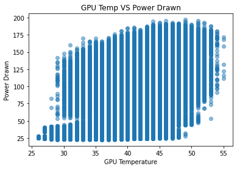

```python
# Plotting scatter plot
plt.scatter(x,y, alpha = 0.5)
plt.xlabel('GPU Temperature')
plt.ylabel('Power Drawn')
plt.title('GPU Temp VS Power Drawn')

# Defining chart size
plt.rcParams['figure.figsize'] = [10, 6]

# Saving Image
# plt.savefig('Images/temp-power.png')
plt.show()
```

```python
# Storing gpu memory utility % and utility % as x and y variable for plotting

# Sampling the data to present a more opaque plot with more distinguished points.
# rows = df_gpu.sample(frac =.10)
# x = rows.gpuMemUtilPerc
# y = rows.gpuUtilPerc

x = df_gpu.gpuMemUtilPerc
y = df_gpu.gpuUtilPerc
```

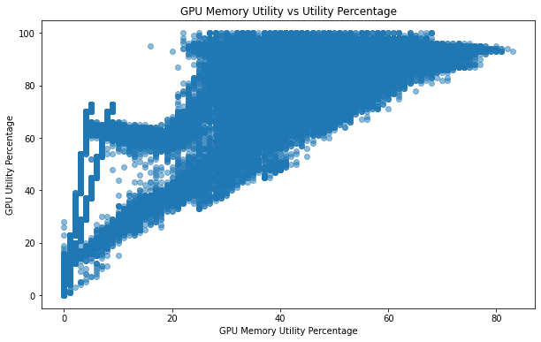

```python
# Plotting scatter plot
plt.scatter(x,y, alpha = 0.5)
plt.xlabel('GPU Memory Utility Percentage')
plt.ylabel('GPU Utility Percentage')
plt.title('GPU Memory Utility vs Utility Percentage')

# Defining chart size
plt.rcParams['figure.figsize'] = [10, 6]

# Saving Image
# plt.savefig('Images/mem-utility.png')
plt.show()
```

```python
# Statistical Sumary of the data
df_gpu.describe()
```

|  | gpuSerial | powerDrawWatt | gpuTempC | gpuUtilPerc | gpuMemUtilPerc |
| --- | --- | --- | --- | --- | --- |
| count | 1.543663e+06 | 1.543663e+06 | 1.543663e+06 | 1.543663e+06 | 1.543663e+06 |
| mean | 3.239836e+11 | 8.919851e+01 | 4.007562e+01 | 6.305822e+01 | 3.341360e+01 |
| std | 1.228836e+09 | 3.975741e+01 | 3.800256e+00 | 4.144813e+01 | 2.300106e+01 |
| min | 3.201181e+11 | 2.255000e+01 | 2.600000e+01 | 0.000000e+00 | 0.000000e+00 |
| 25% | 3.236170e+11 | 4.499000e+01 | 3.800000e+01 | 0.000000e+00 | 0.000000e+00 |
| 50% | 3.236170e+11 | 9.659000e+01 | 4.000000e+01 | 8.900000e+01 | 4.300000e+01 |
| 75% | 3.250170e+11 | 1.213400e+02 | 4.200000e+01 | 9.200000e+01 | 5.100000e+01 |
| max | 3.252171e+11 | 1.970100e+02 | 5.500000e+01 | 1.000000e+02 | 8.300000e+01 |

#### Plotting pair subplots to obtain relationship between variables.

To get the relationship idea between the gpu statistics we plot the pair plot for gpu statistical features.

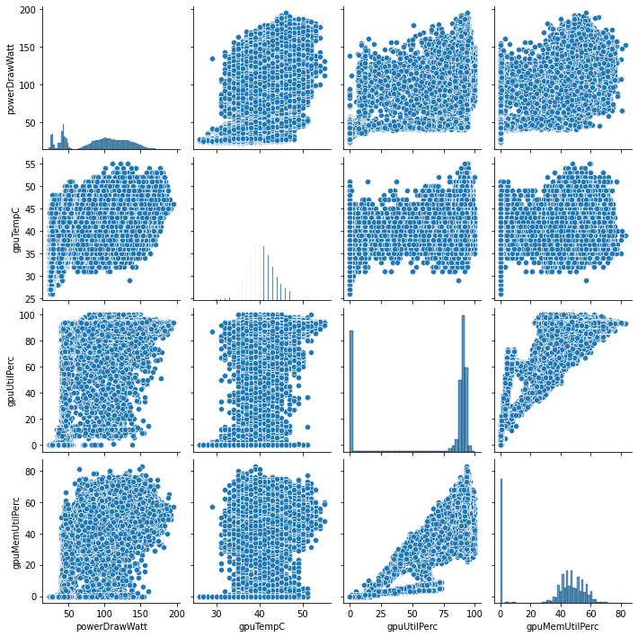

```python
matrix_corr = df_final.iloc[:,4:8]
sns.pairplot(matrix_corr)
```

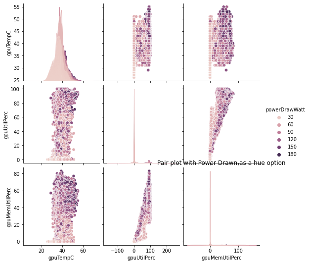

```python
sns.pairplot(matrix_corr, hue ='powerDrawWatt')
plt.title("Pair plot with Power Drawn as a hue option")
plt.show()
```

To quantify the above plots we find out correlation matrix. From the correlation data and heatmap we can observe that there exists a correlation between few variables.  
Correlation coefficient interpretation

- 0 = No relationship between the variables
- +0.3 = weak relationship
- +0.5 = moderate positive relationship
- +0.7 = strong positive linear relationship
- +1 = perfect positive linear relationship

From the matrix we can observe that power drawn has strong positive linear relationship with gpu utility percentage and gpu memory utility percentage which means with the increas in power drawn more gpu utilization and memory utilization. It also has a moderate positive relationship with gpu temp.

```python
# Seperating numerical columns needed to find correlation
gpu_corr = df_gpu.iloc[:,4:8]

# Finding correlation
gpu_corr.corr()
```

|  | powerDrawWatt | gpuTempC | gpuUtilPerc | gpuMemUtilPerc |
| --- | --- | --- | --- | --- |
| powerDrawWatt | 1.000000 | 0.537190 | 0.862673 | 0.870746 |
| gpuTempC | 0.537190 | 1.000000 | 0.505906 | 0.492783 |
| gpuUtilPerc | 0.862673 | 0.505906 | 1.000000 | 0.966571 |
| gpuMemUtilPerc | 0.870746 | 0.492783 | 0.966571 | 1.000000 |

The above correlation coefficient matrix has been plotted as a heatmap thereby making it easier to visualize the relationship with respect to color intensity.

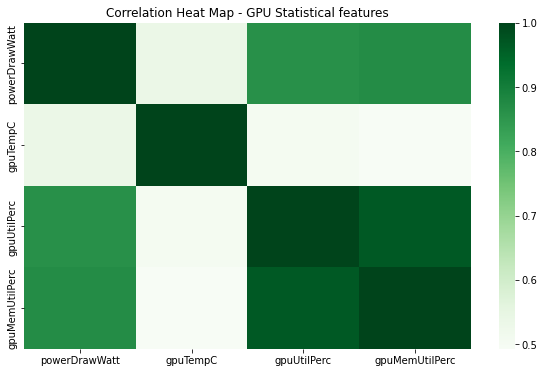

```python
# Plotting Heat Map
plt.figure(figsize=(10, 6))
sns.heatmap(gpu_corr.corr(),cmap='Greens',annot=False)
plt.title('Correlation Heat Map - GPU Statistical features')
# Saving Image
# plt.savefig('Images/Heat-map.png')
plt.show()
```

```python
# Displaying total iterations based on event name
df_final['eventName'].value_counts()
```

```
TotalRender      67756
Saving Config    67682
Uploading        67642
Render           67328
Tiling           67274
Name: eventName, dtype: int64
```

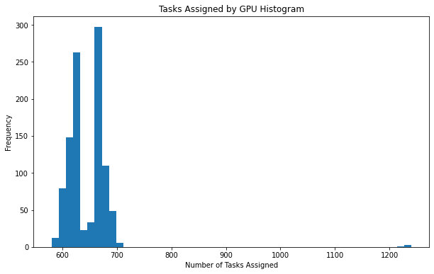

```python
df_check_task['hostname'].value_counts().plot(kind = 'hist', bins=50)
plt.xlabel('Number of Tasks Assigned')
plt.title('Tasks Assigned by GPU Histogram')
plt.rcParams['figure.figsize'] = [15, 8]
# plt.savefig('/tasks-histo.png') # save figure
plt.show()
```

600 to 700 is the range of tasks assigned to majority of GPUs with negligible amount around 1200. From the graph we can see the inconsistent assignment as task handling varies from 600-700 and to even 1200 suggesting scheduling is not consistent and could use improvement to ensure the uniform spread of the load.

#### Analyzing GPU Hardware performance visually

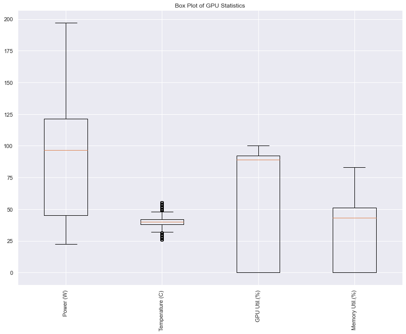

```python
# List of gpu statical labels mentioned in the dataset
gpu_stats = ['Power (W)','Temperature (C)','GPU Util.(%)','Memory Util.(%)']

plt.subplot(1, 2, 1)
plt.boxplot([df_gpu['powerDrawWatt'], df_gpu['gpuTempC'],
df_gpu['gpuUtilPerc'], df_gpu['gpuMemUtilPerc']])

# Add labels
plt.xticks([i+1 for i, x in enumerate(gpu_stats)],
gpu_stats, rotation='vertical')

# Plot Title
plt.title('Box Plot of GPU Statistics')
plt.rcParams['figure.figsize'] = [30, 10]

# Saving Image
# plt.savefig('Images/Box-plot.png')
plt.show()
```

#### Plotting Histogram to visualize the power consumption range

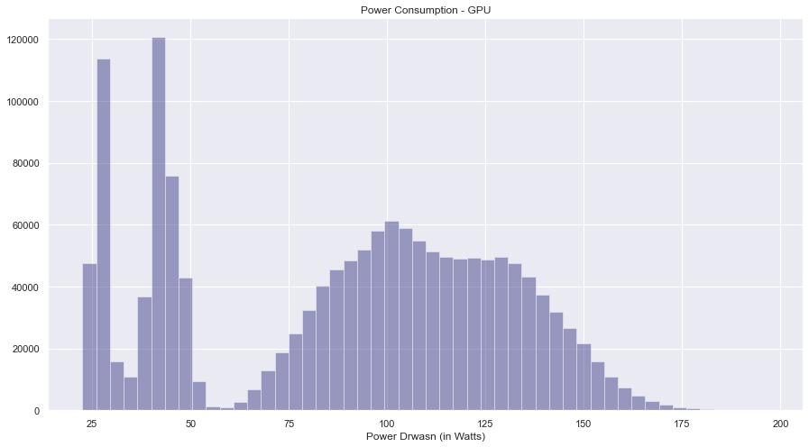

```python
# Setting size and plotting chart
plt.figure(figsize=(15,8))
sns.set()
sns.distplot(df_gpu['powerDrawWatt'], kde = False, color = 'midnightblue', label = "Age")

# Adding Labels and Title
plt.title("Power Consumption - GPU")
plt.xlabel('Power Drwasn (in Watts)')

# Saving Image
#plt.savefig('Images/Powerconsumption.png')
```

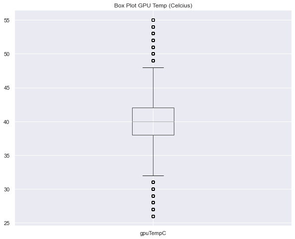

```python
# Plotting box plot
#fig = plt.figure(figsize = (10,7))
df_gpu.boxplot(column = ["gpuTempC"])
plt.title('Box Plot GPU Temp (Celcius)')

# Defining chart size
plt.rcParams['figure.figsize'] = [20, 18]

# Saving Image
#plt.savefig('Images/Box-plot_gpu_temp.png')
plt.show()
```

**GPU Temp**

GPU temp is tightly knitted around 40 degree celcius but it does have a few outliers reaching a min of ~26 to a maximum of ~55 degree celcius. It shows excellent temperature management in gpu cluster

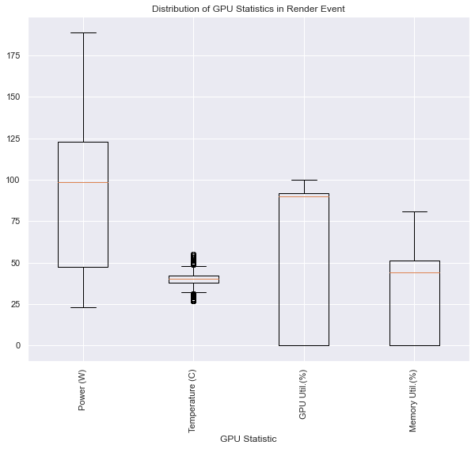

```python
# group by 'render' event type
plt.boxplot(
[df_final[df_final['eventName'] == 'Render']['powerDrawWatt'],
df_final[df_final['eventName'] == 'Render']['gpuTempC'],
df_final[df_final['eventName'] == 'Render']['gpuUtilPerc'],
df_final[df_final['eventName'] == 'Render']['gpuMemUtilPerc']])
# setup labels and titles
plt.title('Distribution of GPU Statistics in Render Event')
plt.xlabel('GPU Statistic')
plt.xticks([i+1 for i, _ in enumerate(gpu_stats)],
gpu_stats, rotation='vertical')
# draw plot
plt.rcParams['figure.figsize'] = [20, 8]
plt.show()
```

We can see that box plot for event render type is almost same is the general box plot for the gpu statistics. This is because from our earlier research (Start of section 8) we know that render event type is the most significant process done with rest of them almost being insignificant.

```python
# Displaying counts based on level
df_final['level'].value_counts()
```

```
12    336345
8       1331
4          6
Name: level, dtype: int64
```

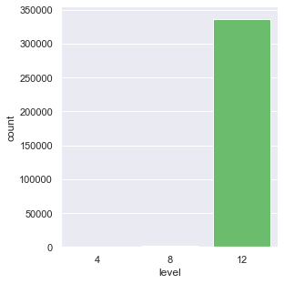

```python
# Plotting level count
sns.catplot(x='level',kind='count', data=df_final, height=4.5, palette='viridis')
```

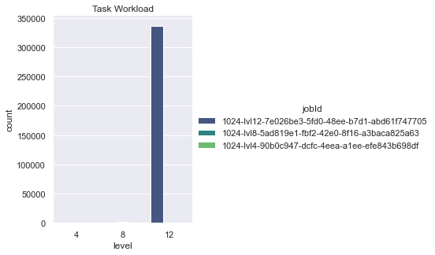

```python
sns.catplot(x='level', kind='count', data=df_final, hue = "jobId", height=4.5, palette='viridis')
plt.title("Task Workload")
```

From the above two graphs it is evident that most of the gpu power is utilized in rendering level 12 that is the inner most zoomed layer of the image.

```python
df_tskid = df_final.loc[df_final['jobId'] == "1024-lvl12-7e026be3-5fd0-48ee-b7d1-abd61f747705"]
df_tskid.info()
```

```
<class 'pandas.core.frame.DataFrame'>
Int64Index: 336345 entries, 0 to 337681
Data columns (total 16 columns):
 #   Column          Non-Null Count   Dtype
---  ------          --------------   -----
 0   timestamp       336345 non-null  datetime64[ns]
 1   hostname_x      336345 non-null  object
 2   gpuSerial       336345 non-null  int64
 3   gpuUUID         336345 non-null  object
 4   powerDrawWatt   336345 non-null  float64
 5   gpuTempC        336345 non-null  int64
 6   gpuUtilPerc     336345 non-null  int64
 7   gpuMemUtilPerc  336345 non-null  int64
 8   hostname_y      336345 non-null  object
 9   eventName       336345 non-null  object
 10  eventType       336345 non-null  object
 11  jobId           336345 non-null  object
 12  taskId          336345 non-null  object
 13  x               336345 non-null  int64
 14  y               336345 non-null  int64
 15  level           336345 non-null  int64
dtypes: datetime64[ns](1), float64(1), int64(7), object(7)
memory usage: 43.6+ MB
```

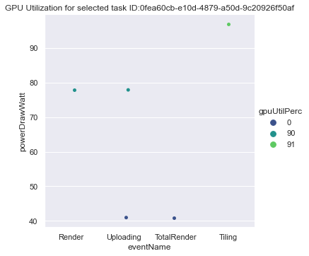

```python
df_tskid = df_final.loc[df_final['taskId'] == "0fea60cb-e10d-4879-a50d-9c20926f50af"] # extracting dataframe for assigned task id
sns.catplot(x='eventName', y = "powerDrawWatt", hue = "gpuUtilPerc", data = df_tskid, height=5, palette='viridis')
plt.title("GPU Utilization for selected task ID:0fea60cb-e10d-4879-a50d-9c20926f50af")
```

```python
df_lvl4 = df_final.loc[df_final['level'] == 4] # slicing dataframe for only level 4 pixels.
```

[output not shown]

[figure not shown]

```python
sns.catplot(x='eventName', y = "powerDrawWatt", hue = "gpuUtilPerc", data = df_lvl4, height = 5, palette='viridis')
plt.title("Event VS Power Drawn - level 4")
plt.xlabel('Event Name')
plt.xticks([i for i, _ in enumerate(['Render', 'Uploading', 'TotalRender', 'Saving Config', 'Tiling'])],
['Render', 'Uploading', 'TotalRender', 'Saving Config', 'Tiling'], rotation='vertical')
```

```python
df_lvl8 = df_final.loc[df_final['level'] == 8] # slicing dataframe for only level 8 pixels.
```

[output not shown]

[figure not shown]

```python
sns.catplot(x='eventName', y = "powerDrawWatt", hue = "gpuUtilPerc", s=5, linewidth=0, data = df_lvl8, height = 5, palette='viridis')
plt.title("GPU Utilization - level 8")
plt.xlabel('Event Name')
plt.xticks([i for i, _ in enumerate(['Render', 'Uploading', 'TotalRender', 'Saving Config', 'Tiling'])],
['Render', 'Uploading', 'TotalRender', 'Saving Config', 'Tiling'], rotation='vertical')
```

To quantify the above graphs and for a clear picture of the power consumption we find the statistical summary of the data bsed on their levels.

```python
# slicing dataframe for only level 12 pixels.
df_lvl12 = df_final.loc[df_final['level'] == 12]
df_lvl4.describe()
```

[output not shown]

```python
df_lvl8.describe()
```

|  | gpuSerial | powerDrawWatt | gpuTempC | gpuUtilPerc | gpuMemUtilPerc | x | y | level |
| --- | --- | --- | --- | --- | --- | --- | --- | --- |
| count | 1.331000e+03 | 1331.000000 | 1331.000000 | 1331.000000 | 1331.000000 | 1331.000000 | 1331.000000 | 1331.0 |
| mean | 3.239717e+11 | 77.030706 | 36.551465 | 53.070624 | 27.624343 | 7.619083 | 7.417731 | 8.0 |
| std | 1.180181e+09 | 42.359766 | 3.858125 | 43.859373 | 23.836917 | 4.654683 | 4.710550 | 0.0 |
| min | 3.201181e+11 | 23.820000 | 28.000000 | 0.000000 | 0.000000 | 0.000000 | 0.000000 | 8.0 |
| 25% | 3.236170e+11 | 28.560000 | 33.000000 | 0.000000 | 0.000000 | 4.000000 | 3.000000 | 8.0 |
| 50% | 3.236170e+11 | 83.400000 | 37.000000 | 86.000000 | 38.000000 | 8.000000 | 7.000000 | 8.0 |
| 75% | 3.250170e+11 | 112.710000 | 39.000000 | 91.000000 | 47.000000 | 12.000000 | 12.000000 | 8.0 |
| max | 3.252171e+11 | 166.190000 | 50.000000 | 95.000000 | 71.000000 | 15.000000 | 15.000000 | 8.0 |

```python
df_lvl12.describe()
```

|  | gpuSerial | powerDrawWatt | gpuTempC | gpuUtilPerc | gpuMemUtilPerc | x | y | level |
| --- | --- | --- | --- | --- | --- | --- | --- | --- |
| count | 3.363450e+05 | 336345.000000 | 336345.000000 | 336345.000000 | 336345.000000 | 336345.000000 | 336345.000000 | 336345.0 |
| mean | 3.239882e+11 | 91.685669 | 40.437328 | 65.466902 | 34.729471 | 127.625548 | 127.190944 | 12.0 |
| std | 1.222649e+09 | 38.602654 | 3.443765 | 40.341873 | 22.478459 | 73.859688 | 73.751450 | 0.0 |
| min | 3.201181e+11 | 22.770000 | 26.000000 | 0.000000 | 0.000000 | 0.000000 | 0.000000 | 12.0 |
| 25% | 3.236170e+11 | 47.450000 | 38.000000 | 0.000000 | 0.000000 | 64.000000 | 64.000000 | 12.0 |
| 50% | 3.236170e+11 | 98.410000 | 40.000000 | 90.000000 | 44.000000 | 128.000000 | 127.000000 | 12.0 |
| 75% | 3.250170e+11 | 122.540000 | 42.000000 | 92.000000 | 51.000000 | 192.000000 | 191.000000 | 12.0 |
| max | 3.252171e+11 | 195.830000 | 55.000000 | 100.000000 | 83.000000 | 255.000000 | 255.000000 | 12.0 |

Here we clearly see see that level 12 terapixel rendering process is the one which consumes the highest power with 91W average power consumption.

## 10. Future Implications

Future implications for the work in this domain are that it can be enhanced to perform predictive techniques to analyze the GPU's performance and reliability. This project can also be used as a basis for scalability planning.

## Personal Reflection

The project taught me how to use a variety of tools and improved my understanding of analyzing a system's performance. It has improved my understanding of using the CRISP-DM methodology. I have also learned various analytical techniques to perform data analysis and get relevant insights using the Python language. I have used Jupyter Notebooks as a literate programming framework along with other popular libraries like Pandas (for data processing), matplotlib, and seaborn (for data visualization), along with GitHub for version control, all of which has helped me hone my skills in using these tools. The assignment also helped me to hone my report writing and data science project management abilities.